# Trees_Redkokosh

Redkokosh Kirill

5/23/2022

Прочитаем набор данных.

```r
data <- Carseats
head(data)
```

```
##   Sales CompPrice Income Advertising Population Price ShelveLoc Age Education
## 1  9.50       138     73          11        276   120       Bad  42        17
## 2 11.22       111     48          16        260    83      Good  65        10
## 3 10.06       113     35          10        269    80    Medium  59        12
## 4  7.40       117    100           4        466    97    Medium  55        14
## 5  4.15       141     64           3        340   128       Bad  38        13
## 6 10.81       124    113          13        501    72       Bad  78        16
##   Urban  US
## 1   Yes Yes
## 2   Yes Yes
## 3   Yes Yes
## 4   Yes Yes
## 5   Yes  No
## 6    No Yes
```

Вывели первые шесть строк.

1. Split the data set into a training set and a test set:

```r
split <- sample.split(data$US, SplitRatio = 0.8)
dataTrain <- subset(data, split == "TRUE")
dataTest <- subset(data, split == "FALSE")
```

2. Fit a regression tree to the training set. Plot the tree, and interpret the results. What test MSE do you obtain:

```r
tree.carseats <- tree(Sales ~ . , dataTrain)
summary(tree.carseats)
```

```
##
## Regression tree:
## tree(formula = Sales ~ ., data = dataTrain)
## Variables actually used in tree construction:
## [1] "ShelveLoc"   "Price"       "Income"      "Age"         "CompPrice"
## [6] "Population"  "Advertising" "Education"
## Number of terminal nodes:  20
## Residual mean deviance:  2.312 = 693.5 / 300
## Distribution of residuals:
##     Min.  1st Qu.   Median     Mean  3rd Qu.     Max.
## -4.80900 -1.00500 -0.05453  0.00000  0.99360  4.71000
```

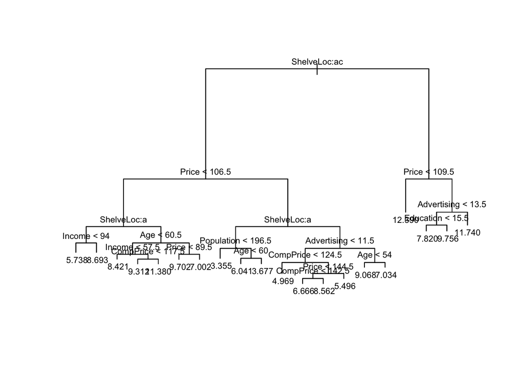

```r
plot(tree.carseats)
text(tree.carseats, cex = 0.7)
```

```r
tree.pred <- predict(tree.carseats, dataTest)
mse(tree.pred, dataTest$Sales)
```

```
## [1] 5.118857
```

3. Use cross-validation in order to determine the optimal level of tree complexity. Does pruning the tree improve the test MSE:

```r
cv.carseats <- cv.tree(tree.carseats, FUN = prune.tree)
cv.carseats
```

```
## $size
##  [1] 20 19 18 17 15 14 13 12 11 10  9  8  7  6  5  4  3  2  1
##
## $dev
##  [1] 1452.882 1481.700 1481.700 1481.700 1491.735 1491.735 1510.350 1498.278
##  [9] 1556.427 1587.918 1579.678 1579.678 1597.275 1618.625 1674.868 1668.749
## [17] 1920.470 2028.023 2622.657
##
## $k
##  [1]      -Inf  26.72426  26.78416  27.14531  28.36290  28.52139  30.56357
##  [8]  33.28107  53.32456  56.10259  62.30582  64.32188  73.05535  79.87744
## [15]  92.50770 123.30078 187.69780 269.25644 623.44825
##
## $method
## [1] "deviance"
##
## attr(,"class")
## [1] "prune"         "tree.sequence"
```

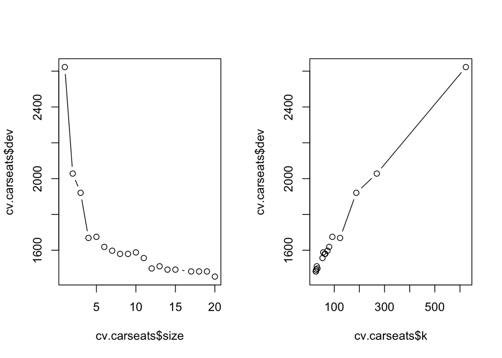

```r
par(mfrow = c(1, 2))
plot(cv.carseats$size, cv.carseats$dev, type = "b")
plot(cv.carseats$k, cv.carseats$dev, type = "b")
```

После размера дерева = 4 ошибка уменьшается намного медленнее, построим дерево c 4 конечными вершинами (листьями).

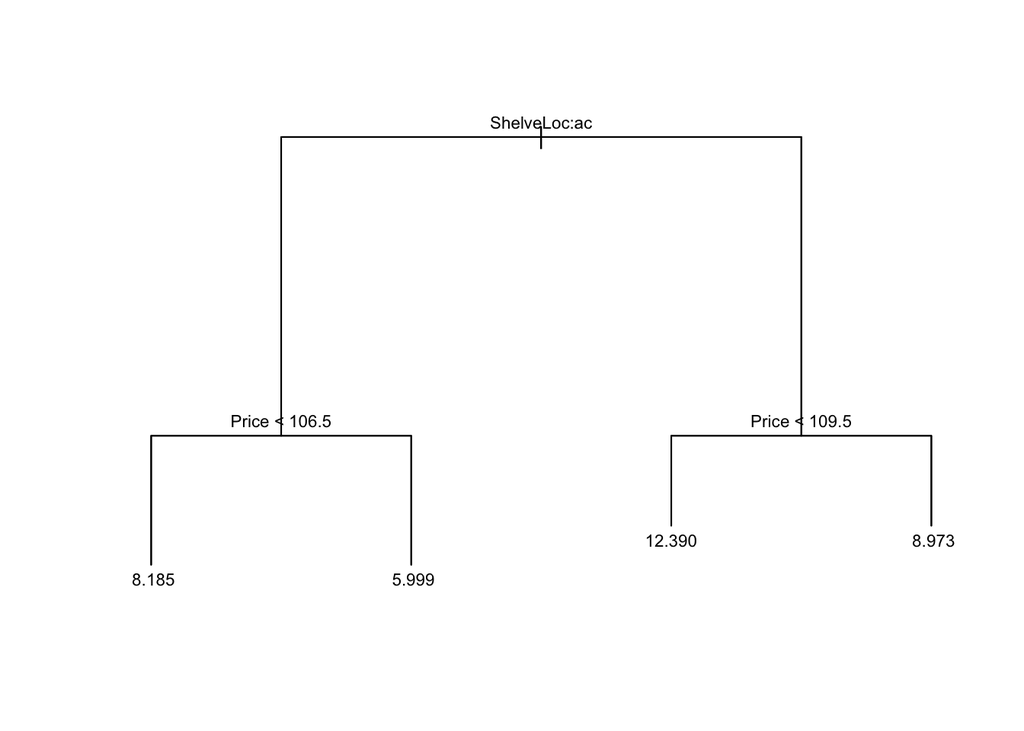

```r
prune.carseats <- prune.tree(tree.carseats, best = 4)
plot(prune.carseats)
text(prune.carseats, cex = 0.7)
```

```r
tree.pred <- predict(prune.carseats, dataTest)
mse(tree.pred, dataTest$Sales)
```

```
## [1] 4.686314
```

На первом этапе происходит по переменной ShelveLoc, то есть расположение является наиболее значимым признаком, после чего на обеих ветвях деление происходит по признаку “цена”. MSE = 4.69, меньше, чем в исходном варианте.

4. Use the bagging approach in order to analyze this data. What test MSE do you obtain:

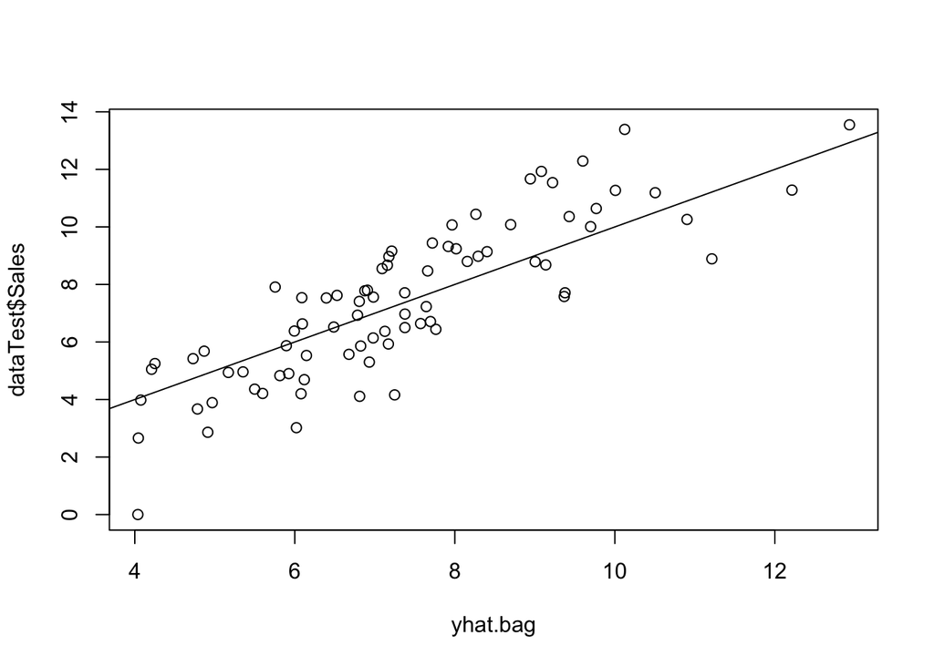

```r
bag.carseats <- randomForest(Sales ~ ., data = dataTrain, mtry = 10, importance = TRUE)
yhat.bag <- predict(bag.carseats, newdata = dataTest)
plot(yhat.bag, dataTest$Sales)
abline(0, 1)
```

```r
mse(yhat.bag, dataTest$Sales)
```

```
## [1] 2.203449
```

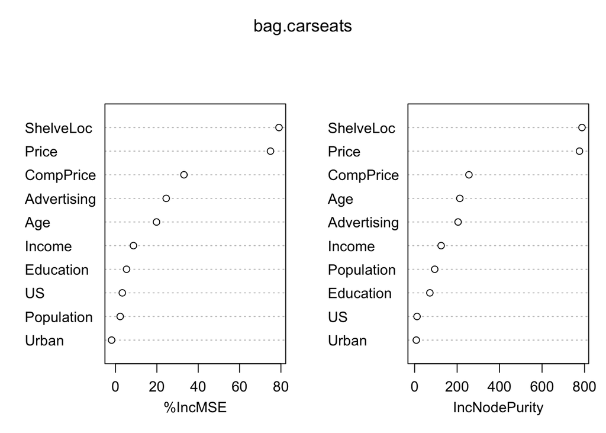

```r
varImpPlot(bag.carseats)
```

Наиболее важными переменными являются ShelveLoc и Price, что уже было отмечено и ранее.

MSE = 2.2, более чем в 2 раза уменьшилось по сравнению с optimally-pruned деревом.

5. Use random forests to analyze this data. What test MSE do you obtain:

```r
bag.carseats <- randomForest(Sales ~ ., data = dataTrain, mtry = 10, importance = TRUE, ntree = 250)
yhat.bag <- predict(bag.carseats, newdata = dataTest)
mse(yhat.bag, dataTest$Sales)
```

```
## [1] 2.083975
```

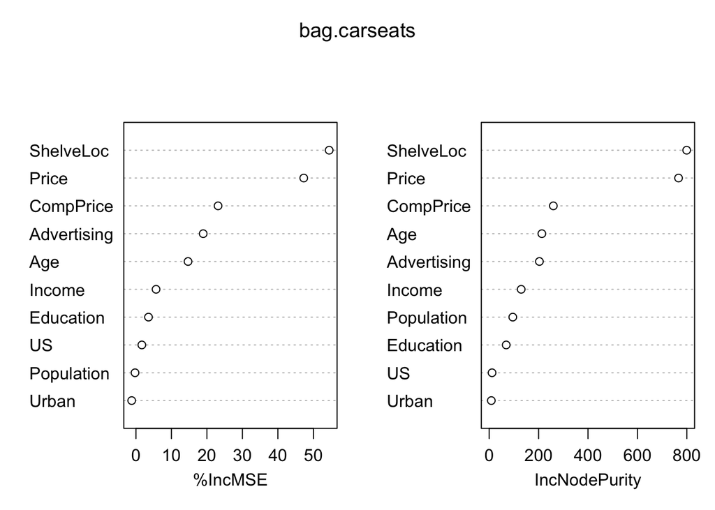

```r
varImpPlot(bag.carseats)
```

```r
bag.carseats <- randomForest(Sales ~ ., data = dataTrain, mtry = 4, importance = TRUE, ntree = 250)
yhat.bag <- predict(bag.carseats, newdata = dataTest)
mse(yhat.bag, dataTest$Sales)
```

```
## [1] 2.338235
```

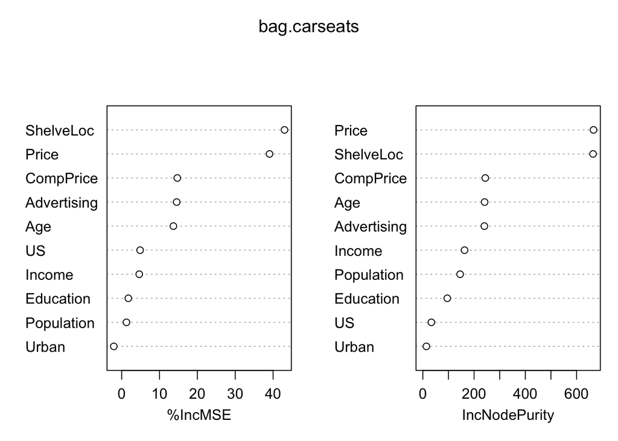

```r
varImpPlot(bag.carseats)
```

В обоих случаях наиболее важными переменными являются ShelveLoc и Price, что уже было отмечено и ранее.

При использовании всех признаков MSE = 2.08. Результат лучше, чем при bagging.

При использовании 4 признаков MSE = 2.34 (рекомендация для деревьев регрессии $\frac p3$).

Возможно количество признаков недостаточно для применения этой рекомендации.

То есть в данном случае стоит попробовать увеличить количество используемых признаков.

```r
bag.carseats <- randomForest(Sales ~ ., data = dataTrain, mtry = 7, importance = TRUE, ntree = 250)
yhat.bag <- predict(bag.carseats, newdata = dataTest)
mse(yhat.bag, dataTest$Sales)
```

```
## [1] 2.209091
```

Попробовав различное количество признаков результата лучше, чем при использовании всех признаков получить не удалось.

6. Now analyze the data using BART, and report your results:

```r
bartfit <- gbart(dataTrain[, 2:11], dataTrain$Sales, x.test = dataTest[, 2:11])
```

[output not shown]

```r
yhat.bart <- bartfit$yhat.test.mean
mse(yhat.bart, dataTest$Sales)
```

```
## [1] 1.178455
```

```r
ord <- order(bartfit$varcount.mean, decreasing = TRUE)
bartfit$varcount.mean[ord]
```

```
##       Price   CompPrice         US1  ShelveLoc1  ShelveLoc2      Urban1
##      25.346      19.303      17.876      17.382      16.994      16.310
##      Urban2         Age  ShelveLoc3  Population         US2      Income
##      16.232      15.967      15.896      15.804      15.737      15.458
## Advertising   Education
##      15.301      14.423
```

MSE=1.18 лучший из результатов. Самая часто встречаемая переменная– Price.